# Ptychodera Cisreg Development: comparative and network analyses

Alberto Perez-Posada

4/30/2024

## About

In this markdown, we will Explore the similarities of several pair of stages between Ptychodera, Amphioxus, and Sea urchin, with an emphasis on the expression of FoxA.

## Load libraries

```r
library(circlize)
library(ComplexHeatmap)
library(cowplot)
library(dplyr)
library(EDASeq)
library(ggplot2)
library(ggplotify)
library(ggpubr)
library(gridExtra)
library(stringr)
library(tidyverse)
require(colorspace)
require(stringr)
```

## Load functions

```r
source("code/r_code/r_functions/sourcefolder.R")

sourceFolder(
  "code/r_code/r_functions",
  recursive = TRUE
  )

sourceFolder(
  "code/r_code/r_general",
  recursive = TRUE
  )
```

## Load Data

We will first load the data of our three species:

```r
# Ptychodera analyses
load("outputs/rda/deseq2.rda")
# Amphioxus reanalysis
load("outputs/rda/blan_reanalysis.rda")
# Purple Sea Urchin reanalysis
load("outputs/rda/spur_reanalysis.rda")
```

We will load the TF data as well as the comparative data to explore commonalities across the three species.

```r
# General
load("outputs/rda/TF_annotation.rda")
# ptychodera
load("outputs/rda/tf_analysis.rda")
# age
load("outputs/rda/geneage.rda")
# amphioxus
load("outputs/rda/tf_analysis_blan.rda")
# sea urchin
load("outputs/rda/tf_analysis_spur.rda")
# comparative
load("outputs/rda/species_comparison.rda")

pfla_genenames <-
  read.delim2(
    file = "outputs/functional_annotation/eggnog/emapper.annotations",
    skip = 3,
    header = TRUE
  )[,c(1,5,13)]
pfla_genenames <- pfla_genenames[pfla_genenames$predicted_gene_name != "",]
```

## Comparison of Transcription Factor profiles throughout development

We will plot all the TF barplots together in one grid:

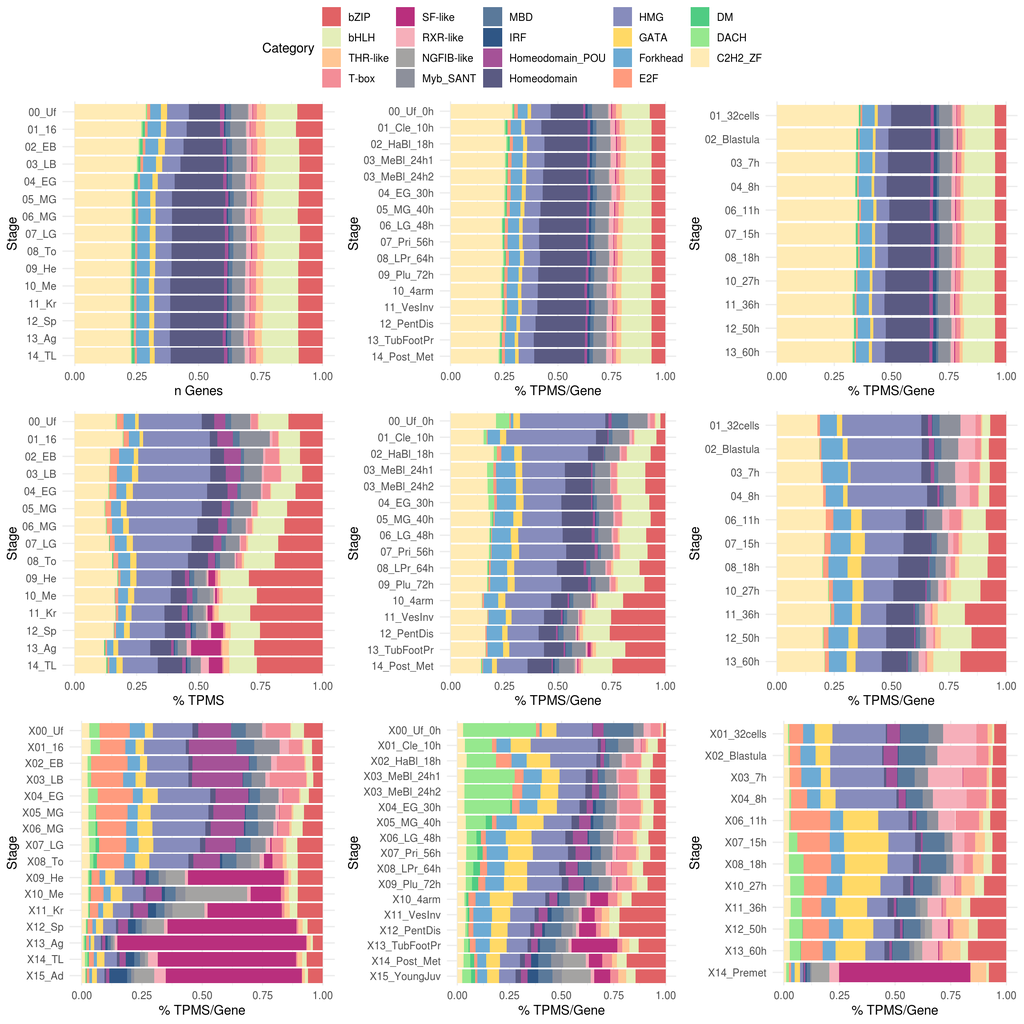

```r
ggarrange(
  pfla_tfs_ngenes_plot,
  spur_tfs_ngenes_plot,
  blan_tfs_ngenes_plot,
  pfla_tfs_expgenes_plot,
  spur_tfs_expgenes_plot,
  blan_tfs_expgenes_plot,
  pfla_tf_EXPNGEN_plot,
  spur_tf_EXPNGEN_plot,
  blan_tf_EXPNGEN_plot,
  ncol=3,
  nrow=3,
  common.legend=T
)
```

# Comparison of 1-to-1 TFs using blast best RBHs

We will use Blast reciprocal best hits (RBHs or rbhs) as a proxy for orthology between the two pairs of species.

```r
# orthofinder 1to1 orthologues
OF_pfla_blan <- read.delim2("outputs/comparative/20240404_orthofinder/one_to_one_orthologues/1to1_pfla_blan.tsv", header = TRUE)
OF_pfla_spur <- read.delim2("outputs/comparative/20240404_orthofinder/one_to_one_orthologues/1to1_pfla_spur.tsv", header = TRUE)

# blast reciprocal best hits 1to1 orthologues
rbh_pfla_blan <- read.delim2("outputs/comparative/rbh/pfla_blan_rbh.tsv", header = FALSE)
rbh_pfla_blan[,2] <- gsub(" ","",rbh_pfla_blan[,2])
rbh_pfla_blan[,1] <- gsub("\\.p[0-9]+","",rbh_pfla_blan[,1])

rbh_pfla_spur <- read.delim2("outputs/comparative/rbh/pfla_spur_rbh.tsv", header = FALSE)
rbh_pfla_spur[,2] <- gsub(" ","",rbh_pfla_spur[,2])
rbh_pfla_spur[,1] <- gsub("\\.p[0-9]+","",rbh_pfla_spur[,1])
```

## Ptychodera and Sea Urchin

We will subset the datasets to keep only the TFs of each species.

```r
pf_tfs <- pfla_rna_counts[rownames(pfla_rna_counts) %in% pfla_tfs$id,]
sp_tfs <- spur_vsd[rownames(spur_vsd) %in% spur_tfs$id,]

# Samples for rowmeans_by repl
pf_samples = levels(condition_x)
sp_samples = unique(sub("_.$", "", colnames(sp_tfs)))

# Family/orthology data
pf_sp_o = unique(OF_pfla_spur)
```

We transform the data:

```r
pf_tfs = qnorm(pf_tfs)
pf_tfs = tidyup(pf_tfs, highlyvariable = FALSE)
pf_tfs = rep2means(pf_samples,pf_tfs)

sp_tfs = qnorm(sp_tfs)
sp_tfs = tidyup(sp_tfs, highlyvariable = FALSE)
sp_tfs = rep2means(sp_samples,sp_tfs)
```

And we merge them using the `comparABle` functions, keeping common one-to-one TF orthologues.

```r
# MERGE
pf_sp_o = pair2id(pf_sp_o)
pf_sp_merge_ab_tfs <- mergedata(pf_tfs,sp_tfs,pf_sp_o)
```

We generate here the pairwise correlations:

```r
# CORRELATIONS
pf_sp_rbh_cors_tfs <- rawcorsp(pf_sp_merge_ab_tfs$a_o,pf_sp_merge_ab_tfs$b_o)

pf_sp_tfs_jsd_rel <- relativise(pf_sp_rbh_cors_tfs$js)

pf_sp_tfs_jsd_hm <-
  Heatmap(
    pf_sp_tfs_jsd_rel,
    name = "JSD\nPf/Sp",
    cluster_rows = F, cluster_columns = F,
    show_row_names = F, show_column_names = F,
    col = brewer.pal(10,"RdBu"),
    column_names_gp = gpar(cex = .8), row_names_gp = gpar(cex = .8),
    left_annotation = devstages_ha_rows(rownames(pf_sp_tfs_jsd_rel)),
    top_annotation = quick_ha(colnames(pf_sp_tfs_jsd_rel),"Purple-Orange", rev = TRUE)
    )
```

## Ptychodera and Amphioxus

We will subset the datasets to keep only the TFs of each species.

```r
# load tfs
pf_tfs <- pfla_rna_counts[rownames(pfla_rna_counts) %in% pfla_tfs$id,]
blan_tfs$id <- translate_ids(sub("_..*","",blan_tfs$id),bl_brala)
bl_tfs <- blan_counts[rownames(blan_counts) %in% blan_tfs$id,]

# Samples for rowmeans_by repl
pf_samples = levels(condition_x)
bl_samples = unique(sub("_.$", "", colnames(bl_tfs)))

# Family/orthology data
pf_bf_o = unique(rbh_pfla_blan)
```

We transform the data:

```r
pf_tfs = qnorm(pf_tfs)
pf_tfs = tidyup(pf_tfs, highlyvariable = FALSE) # remove genes with 0 tpms
pf_tfs = rep2means(pf_samples,pf_tfs)

bl_tfs = qnorm(bl_tfs)
bl_tfs = tidyup(bl_tfs, highlyvariable = FALSE)
bl_tfs = rep2means(bl_samples,bl_tfs) # remove genes with 0 tpms
```

And we merge them using the `comparABle` functions, keeping common one-to-one TF orthologues.

```r
# MERGE
pf_bf_o = pair2id(pf_bf_o)
pf_bl_merge_ab_tfs <- mergedata(pf_tfs,bl_tfs,pf_bf_o)
```

We generate here the pairwise correlations:

```r
# CORRELATIONS
pf_bl_rbh_cors_tfs <- rawcorsp(pf_bl_merge_ab_tfs$a_o,pf_bl_merge_ab_tfs$b_o)
pf_bl_tfs_jsd_rel <- relativise(pf_bl_rbh_cors_tfs$js)

pf_bl_tfs_jsd_hm <-
  Heatmap(
    pf_bl_tfs_jsd_rel,
    name = "JSD\nPf/Bl",
    cluster_rows = F, cluster_columns = F,
    show_row_names = F, show_column_names = F,
    col = brewer.pal(10,"RdBu"),
    column_names_gp = gpar(cex = .8), row_names_gp = gpar(cex = .8),
    left_annotation = devstages_ha_rows(rownames(pf_bl_tfs_jsd_rel)),
    top_annotation = quick_ha(colnames(pf_bl_tfs_jsd_rel),"Purple-Yellow", rev = TRUE)
    )
```

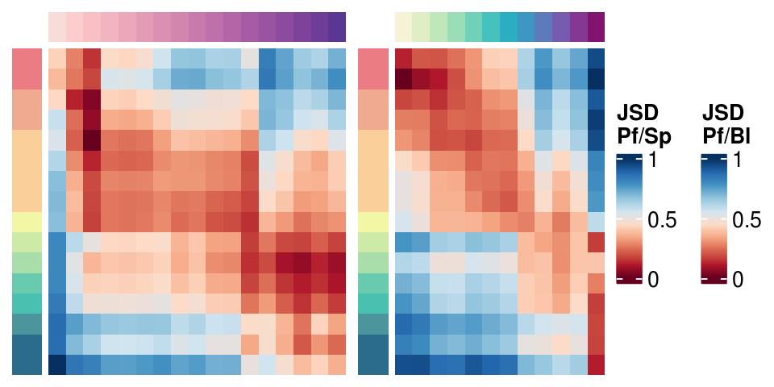

```r
draw(pf_sp_tfs_jsd_hm+pf_bl_tfs_jsd_hm)
```

## Comparing gastrulas at the TF level:

### Pfla and Spur

From here we will compare ptychodera Early Gastrula with Sea Urchin Mesenchyme Blastula.

```r
# COMMON GENES IN CORRELATIONS
pf_sp_rbh <- pair2id(unique(rbh_pfla_spur))
pf_sp_merge_abl_tfs_rbh <- mergedata(pf_tfs,sp_tfs,o = pf_sp_rbh)
pf_sp_rbh_cors_tfs_rbh <- rawcorsp(pf_sp_merge_abl_tfs_rbh$a_o,pf_sp_merge_abl_tfs_rbh$b_o)

pf_sp_stages_tfs =
  list(
    a = c("04_EG","04_EG"),
    b = c("03_MeBl_24h1","03_MeBl_24h2")
  )

pf_sp_common_tfs_cor <- get_high_cor_genes(
  mat = pf_sp_rbh_cors_tfs_rbh$js,
  a_o = pf_sp_merge_abl_tfs_rbh$a_o,
  b_o = pf_sp_merge_abl_tfs_rbh$b_o,
  stages = pf_sp_stages_tfs,
  o = pf_sp_rbh
)
```

```
## [1] "Subsetting count matrices"
## [1] "Model fitting and top genes"
```

And here the plots:

```r
pf_sp_hco = pf_sp_common_tfs_cor$hicor_matrices$cor_04_EG__03_MeBl_24h2
pf_sp_hco_lm_wls = pf_sp_common_tfs_cor$hicor_topgenes$cor_04_EG__03_MeBl_24h2$lm
pf_sp_filt = which(rownames(pf_sp_hco) %in% pf_sp_common_tfs_cor$hicor_topgenes$cor_04_EG__03_MeBl_24h2$top_genes$one2one )

foxa <- "TCONS_00009611"
pf_sp_foxa_pair <- pf_sp_rbh$one2one[pf_sp_rbh$a==foxa]
pf_sp_foxa_idx <- which(row.names(pf_sp_hco) == pf_sp_foxa_pair)

pf_sp_scatter_foxa <-
  ggplot(data = pf_sp_hco, aes(x = a, y = b)) +
  geom_point(pch = 20, col = rgb(0.1,0.1,0.1,0.2)) +
  geom_abline(slope = pf_sp_hco_lm_wls$coefficients[2], intercept = pf_sp_hco_lm_wls$coefficients[1], col = gb_col[["blue2"]], lwd = 1.25) +
  geom_point(data = pf_sp_hco[pf_sp_filt,], pch = 21, col = "tomato3", bg = "tan1", size = 3) +
  geom_point(data = pf_sp_hco[pf_sp_foxa_idx,], pch = 21,  col = gb_col[["blue2"]], bg = gb_col[["blue1"]], size = 3.5) +
  geom_text(aes(x = pf_sp_hco[pf_sp_foxa_idx,1]+0.05, y = pf_sp_hco[pf_sp_foxa_idx,2]+0.05, label = "FoxA"),
            col = "black", size = 4, hjust = 0, vjust = 0) +
  labs(title = "P. flava LG / S. purpuratus MeBl") +
  theme_classic()+
  labs(x = "P. flava (log counts)", y = "S. purpuratus (log counts)")
```

Some of these TFs are driving similarities between these two stages, and FoxA is found to be highly expressed as well.

### Pfla and Amphi

From here we will compare ptychodera Late Gastrula with amphioxus 18h.

```r
# COMMON GENES IN CORRELATIONS
pf_bl_rbh <- pair2id(unique(rbh_pfla_blan))
pf_bl_merge_ab_tfs_rbh <- mergedata(pf_tfs,bl_tfs,o = pf_bl_rbh)
pf_bl_rbh_cors_tfs_rbh <- rawcorsp(pf_bl_merge_ab_tfs_rbh$a_o,pf_bl_merge_ab_tfs_rbh$b_o)

pf_bl_stages_tfs =
 list(
    a = c("04_EG","05_MG","05_MG","06_MG","07_LG","09_He"),
    b = c("06_11h","07_15h","08_18h","08_18h","08_18h","14_Premet")
  )

pf_bl_common_tfs_cor <- get_high_cor_genes(
  mat = pf_bl_rbh_cors_tfs_rbh$js,
  a_o = pf_bl_merge_ab_tfs_rbh$a_o,
  b_o = pf_bl_merge_ab_tfs_rbh$b_o,
  stages = pf_bl_stages_tfs,
  o = pf_bl_rbh
)
```

```
## [1] "Subsetting count matrices"
## [1] "Model fitting and top genes"
```

```r
pf_bl_hco = pf_bl_common_tfs_cor$hicor_matrices$cor_07_LG__08_18h
pf_bl_hco_lm_wls = pf_bl_common_tfs_cor$hicor_topgenes$cor_07_LG__08_18h$lm
pf_bl_filt = which(rownames(pf_bl_hco) %in% pf_bl_common_tfs_cor$hicor_topgenes$cor_07_LG__08_18h$top_genes$one2one )

foxa <- "TCONS_00009611"
pf_bl_foxa_pair <- pf_bl_rbh$one2one[pf_bl_rbh$a==foxa]
pf_bl_foxa_idx <- which(row.names(pf_bl_hco) == pf_bl_foxa_pair)

pf_bl_scatter_foxa <-
  ggplot(data = pf_bl_hco, aes(x = a, y = b)) +
  geom_point(pch = 20, col = rgb(0.1,0.1,0.1,0.2)) +
  geom_abline(slope = pf_bl_hco_lm_wls$coefficients[2], intercept = pf_bl_hco_lm_wls$coefficients[1], col = gb_col[["blue2"]], lwd = 1.25) +
  geom_point(data = pf_bl_hco[pf_bl_filt,], pch = 21, col = "tomato3", bg = "tan1", size = 3) +
  geom_point(data = pf_bl_hco[pf_bl_foxa_idx,], pch = 21, col = gb_col[["blue2"]], bg = gb_col[["blue1"]], size = 3.5) +
  geom_text(aes(x = pf_bl_hco[pf_bl_foxa_idx,1]+0.05, y = pf_bl_hco[pf_bl_foxa_idx,2]+0.05, label = "FoxA"),
            col = "black", size = 4, hjust = 0, vjust = 0) +
  labs(title = "P. flava LG / B. lanceolatum 18h") +
  theme_classic()+
  labs(x = "P. flava (log counts)", y = "B. lanceolatum (log counts)")
```

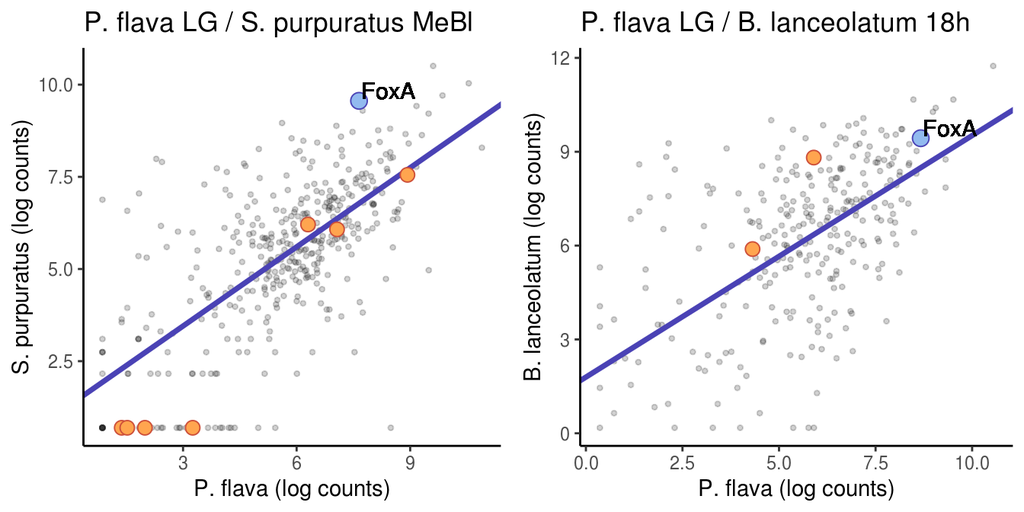

```r
plot_grid(
  pf_sp_scatter_foxa,
  pf_bl_scatter_foxa,
  ncol = 2
  )
```

## Expression of FoxA in each species:

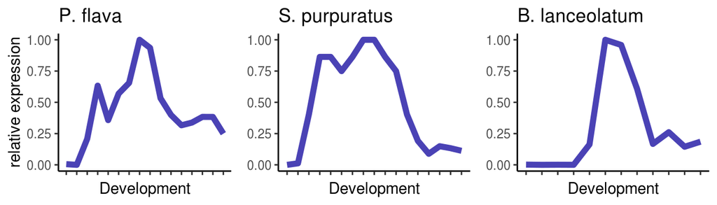

```r
# plot 1
pfla_foxa <-
  ggplot(
    data = data.frame(
      stages_pfla = 1:16,
      foxa = relativise(pf_tfs[foxa,]) # as.numeric(scale(as.numeric(pf_tfs[foxa,])))
    ),
    aes(x = stages_pfla, y = foxa)
  ) +
  geom_line(lwd = 2, col = gb_col[["blue2"]]) +
  ylab("relative expression")+
  scale_x_continuous(breaks = 1:16, labels = rep("",16))+
  theme_classic()+
  ggtitle("P. flava")+
  xlab("Development")+
  theme(axis.text.x = element_text(angle = 90, vjust = 0.5, hjust=1))

# plot 2
spur_foxa <-
  ggplot(
    data = data.frame(
      stages_spur = 1:17,
      foxa = as.numeric(relativise(pf_sp_merge_abl_tfs_rbh$b_o[pf_sp_foxa_pair,]))# t(scale(t(pf_sp_merge_abl_tfs_rbh$b_o)))[rownames(pf_sp_merge_abl_tfs_rbh$b_o) == pf_sp_foxa_pair,]
    ),
    aes(x = stages_spur, y = foxa)
  ) +
  geom_line(lwd = 2, col = gb_col[["blue2"]]) +
  scale_x_continuous(breaks = 1:17, labels = rep("",17))+
  theme_classic()+
  ggtitle("S. purpuratus")+
  xlab("Development")+
  ylab(NULL)+
  theme(axis.text.x = element_text(angle = 90, vjust = 0.5, hjust=1))

# plot 2
blan_foxa <-
  ggplot(
    data = data.frame(
      stages_blan = 1:12,
      foxa = as.numeric(relativise(pf_bl_merge_ab_tfs$b_o[pf_bl_foxa_pair,]))# t(scale(t(pf_bl_merge_ab_tfs$b_o)))[rownames(pf_bl_merge_ab_tfs$b_o) == foxa_pair,]
    ),
    aes(x = stages_blan, y = foxa)
  ) +
  geom_line(lwd = 2, col = gb_col[["blue2"]]) +
  scale_x_continuous(breaks = 1:12, labels = rep("",12))+
  theme_classic()+
  ggtitle("B. lanceolatum")+
  xlab("Development")+
  ylab(NULL)+
  theme(axis.text.x = element_text(angle = 90, vjust = 0.5, hjust=1))

plot_grid(
  pfla_foxa,
  spur_foxa,
  blan_foxa,
  nrow = 1
)
```

## FoxA in the P.flava networks

We will load the graph analysis data:

```r
library(igraph)
load("outputs/rda/graph_analysis.rda")
```

```r
foxa_centr <- as_ggplot( as.grob( function(){
  X = relativise(EB_vs_LG$centrality_changes_TFs$a)
  Y = relativise(EB_vs_LG$centrality_changes_TFs$b)

  plot(
    main = "Changes in centrality of TFs",
    x = X,
    y = Y,
    pch = 19,
    col = alpha(gb_col[["black1"]],0.25),
    bty="n",
    xlab = "Early Gastrula",
    ylab = "Late Gastrula"
  )

  points(
    x = X[rownames(EB_vs_LG$centrality_changes_TFs) == foxa],
    y = Y[rownames(EB_vs_LG$centrality_changes_TFs) == foxa],
    pch = 21, cex = 1.5,
    col = gb_col[["blue2"]],
    bg = gb_col[["blue1"]]
  )

  text(
    x = X[rownames(EB_vs_LG$centrality_changes_TFs) == foxa],
    y = Y[rownames(EB_vs_LG$centrality_changes_TFs) == foxa],
    "FoxA",
    pos = 3
  )
}))
```

```r
# influence

inf <- EB_vs_LG$influence_results$influence_table

# 'translate' the gene ids to known gene names using a small function
inf$genename <-
  translate_ids(x = inf$factor,dict = pfla_genenames)

foxa_inf <-
  as_ggplot( as.grob( function(){

    plot(
      inf$factor_fc,
      inf$influence_score,
      pch=19,
      col=alpha(gb_col[["black1"]],0.25),
      xlab="log2fold change of TF",
      ylab="ANANSE influence score",
      main="Main factors",
      bty="n",
      xlim=c(0,max(inf$factor_fc)+1)
    )
    points(
      inf$factor_fc[inf$factor == foxa],
      inf$influence_score[inf$factor == foxa],
      pch = 21, cex = 1.5,
      col = gb_col[["blue2"]],
      bg = gb_col[["blue1"]]
    )
    text(
      inf$factor_fc[inf$factor == foxa],
      inf$influence_score[inf$factor == foxa],
      "FoxA",
      pos = 3
    )
  }))
```

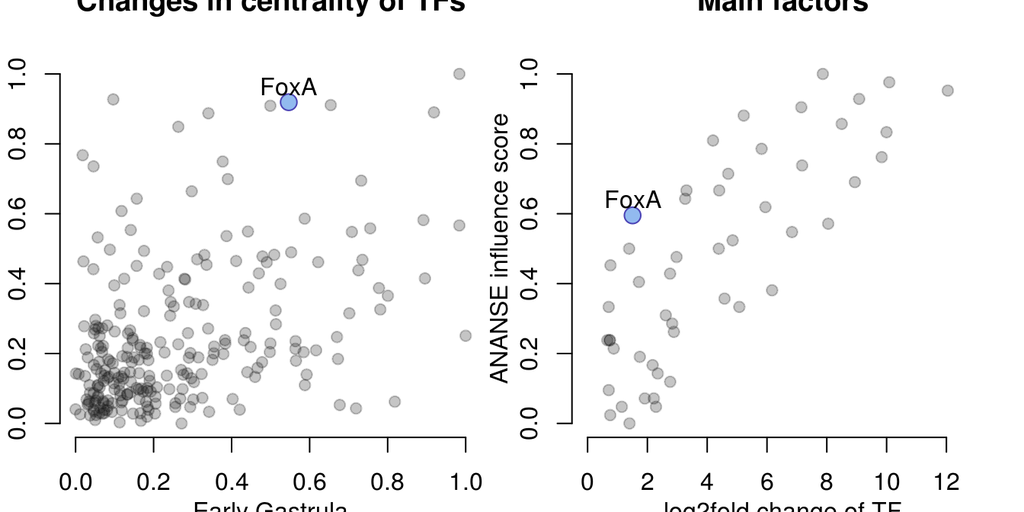

```r
plot_grid(
  foxa_centr,
  foxa_inf,
  ncol = 2
)
```

## Well-known networks of development from deuterostomes in Ptychodera

```r
genes_kernels <-
  read.table(
    "outputs/functional_annotation/grn_homologs/genes_orthologues_grn_kernels.tsv",
    sep = "\t",
    header = TRUE
    )
```

### Endomesodermal kernel

The Ptychodera homologs of the endomesodermal kernel described in Sea Urchins, expressed and interacting in the Late Gastrula network:

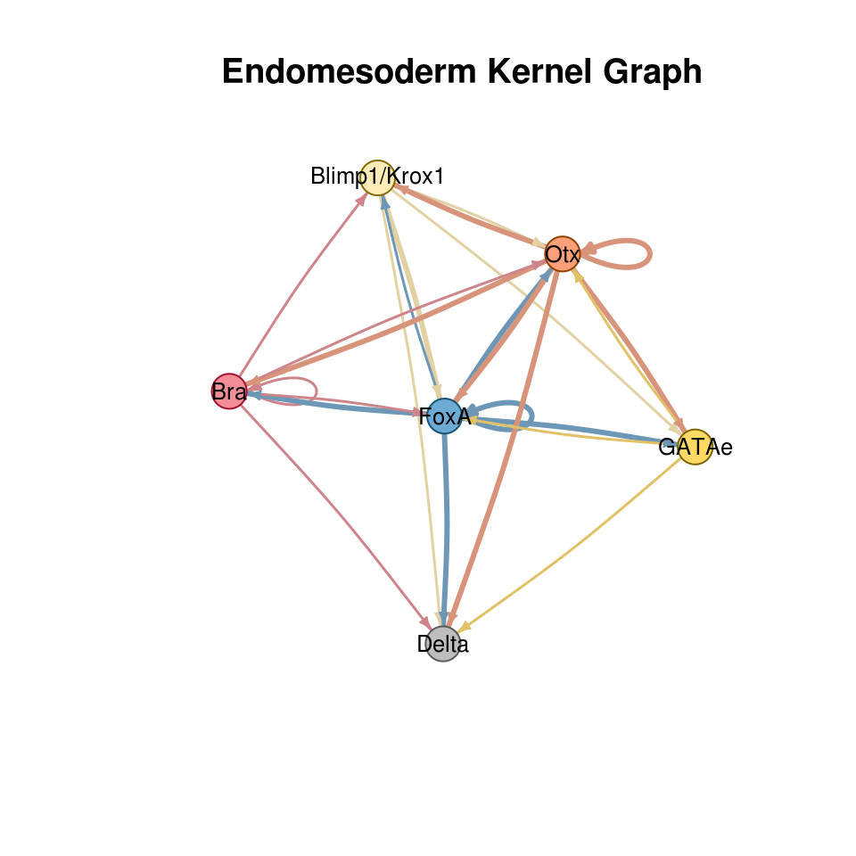

```r
# Load orthologs of endomesodermal kernel
genes_endomesod <-
  genes_kernels[
    genes_kernels$kernel == "endomesoderm",
  ]

# Create induced subgraph
endomesod_graph <-
  induced_subgraph(
    g_LG,
    vids = V(g_LG)[V(g_LG)$name %in% genes_endomesod$id],
    impl = "copy_and_delete"
  )
endomesod_graph <- subgraph_with_top_edges_per_tg(g = endomesod_graph, top = 3, mode = "both")

V(endomesod_graph)$col[V(endomesod_graph)$col==""] <- "gray"
V(endomesod_graph)$genename <- translate_ids(x = V(endomesod_graph)$name, dict = genes_endomesod[,c(4,6)])

E(endomesod_graph)$w <- as.numeric(cut(E(endomesod_graph)$weight,c(.7,quantile(E(endomesod_graph)$weight,.5),1), labels = c(1,2)))
E(endomesod_graph)$col = tail_of(endomesod_graph,E(endomesod_graph))$col

## direct genes involved
set.seed(14)
plot(
  endomesod_graph,
  vertex.color = V(endomesod_graph)$col,
  vertex.frame.color = darken(V(endomesod_graph)$col,.5),
  vertex.label = V(endomesod_graph)$genename,
  vertex.label.family = "Helvetica",
  vertex.label.color = "black",
  vertex.label.cex = .8,
  edge.width = 1.5*E(endomesod_graph)$w,
  edge.arrow.size = 0.1 * (E(endomesod_graph)$w*2),
  edge.color = darken(E(endomesod_graph)$col),
  # edge.color = rgb(0,0,0,0.2),
  layout = layout_with_graphopt(endomesod_graph),
  edge.curved = .05,
  main = "Endomesoderm Kernel Graph"
)
```

```r
n_genes_endomesod <- length(unique(genes_endomesod$id))
n_tfs_endomesod <- length(which( unique(genes_endomesod$id) %in% pfla_attributes_list[[2]]$id ))

endomesod_null_p =
  ananse_null_distribution_degree(
    g = g_LG,
    tfs = pfla_attributes_list[[2]]$id,
    n_genes = n_genes_endomesod,
    n_tfs = n_tfs_endomesod
  )
```

```
## Starting subsampling, 100000 iterations, 6 genes, of which forcing 5 to be TFs
```

```
## calculating the relative frequency of disconnected genes...
```

```
## Expected probability of finding 6 genes (5 of which are TFs) all connected:
## p(0) = 0.15776
```

### Axial mesoderm kernel

The Ptychodera homologs of the axial mesoderm kernel described in Chordates, expressed and interacting in the Late Gastrula network:

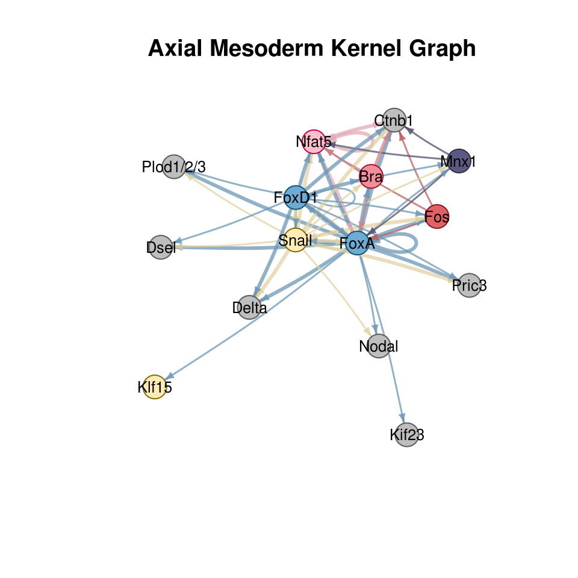

```r
# Load orthologs of axial mesoderm kernel
genes_axmesod <-
  genes_kernels[
    genes_kernels$kernel == "axial_mesoderm",
  ]

# Create induced subgraph
axmesod_graph <-
  induced_subgraph(
    g_LG,
    vids = V(g_LG)[V(g_LG)$name %in% genes_axmesod$id],
    impl = "copy_and_delete"
  )
axmesod_graph <- subgraph_with_top_edges_per_tg(g = axmesod_graph, top = 3, mode = "both")

V(axmesod_graph)$col[V(axmesod_graph)$col==""] <- "gray"
V(axmesod_graph)$genename <- translate_ids(x = V(axmesod_graph)$name, dict = genes_axmesod[,c(4,6)])

E(axmesod_graph)$w <- as.numeric(cut(E(axmesod_graph)$weight,c(.7,quantile(E(axmesod_graph)$weight,.5),1), labels = c(1,2)))
E(axmesod_graph)$col = tail_of(axmesod_graph,E(axmesod_graph))$col

set.seed(146)
plot(
  axmesod_graph,
  vertex.color = V(axmesod_graph)$col,
  vertex.frame.color = darken(V(axmesod_graph)$col,.5),
  vertex.label = V(axmesod_graph)$genename,
  vertex.label.family = "Helvetica",
  vertex.label.color = "black",
  vertex.label.cex = .8,
  edge.width = 1.5*E(axmesod_graph)$w,
  edge.arrow.size = 0.1 * (E(axmesod_graph)$w*2),
  edge.color = alpha(darken(E(axmesod_graph)$col),.75),
  layout = layout_with_graphopt(axmesod_graph),
  edge.curved = .05,
  main = "Axial Mesoderm Kernel Graph"
)
```

```r
n_genes_axmesod <- length(unique(genes_axmesod$id))
n_tfs_axmesod <- length(which( unique(genes_axmesod$id) %in% pfla_attributes_list[[2]]$id ))

axmesod_null_p =
  ananse_null_distribution_degree(
    g = g_LG,
    tfs = pfla_attributes_list[[2]]$id,
    n_genes = n_genes_axmesod,
    n_tfs = n_tfs_axmesod
  )
```

```
## Starting subsampling, 100000 iterations, 17 genes, of which forcing 10 to be TFs
```

```
## calculating the relative frequency of disconnected genes...
```

```
## Expected probability of finding 17 genes (10 of which are TFs) all connected:
## p(0) = 0.07352
```

## Saving PDFs of plots

```r
pdf("graphics/4AB.pdf", width = 7, height = 3.5)
draw(pf_sp_tfs_jsd_hm+pf_bl_tfs_jsd_hm)
dev.off()
```

```r
pdf("graphics/4CD.pdf", width = 7, height = 3.5)
plot_grid(
  pf_sp_scatter_foxa,
  pf_bl_scatter_foxa,
  ncol = 2
  )
dev.off()
```

```r
pdf("graphics/4EFG.pdf", width = 7, height = 2)
plot_grid(
  pfla_foxa,
  spur_foxa,
  blan_foxa,
  nrow = 1
)
dev.off()
```

```r
pdf("graphics/4HI.pdf", width = 7, height = 3.5)
plot_grid(
  foxa_centr,
  foxa_inf,
  ncol = 2
)
dev.off()
```

```r
pdf("graphics/4JK.pdf", width = 5, height = 5)
set.seed(14)
plot(
  endomesod_graph,
  vertex.color = V(endomesod_graph)$col,
  vertex.frame.color = darken(V(endomesod_graph)$col,.5),
  vertex.label = V(endomesod_graph)$genename,
  vertex.label.family = "Helvetica",
  vertex.label.color = "black",
  vertex.label.cex = .8,
  edge.width = 1.5*E(endomesod_graph)$w,
  edge.arrow.size = 0.1 * (E(endomesod_graph)$w*2),
  edge.color = darken(E(endomesod_graph)$col),
  # edge.color = rgb(0,0,0,0.2),
  layout = layout_with_graphopt(endomesod_graph),
  edge.curved = .05,
  main = "Endomesoderm Kernel Graph"
)
set.seed(146)
plot(
  axmesod_graph,
  vertex.color = V(axmesod_graph)$col,
  vertex.frame.color = darken(V(axmesod_graph)$col,.5),
  vertex.label = V(axmesod_graph)$genename,
  vertex.label.family = "Helvetica",
  vertex.label.color = "black",
  vertex.label.cex = .8,
  edge.width = 1.5*E(axmesod_graph)$w,
  edge.arrow.size = 0.1 * (E(axmesod_graph)$w*2),
  edge.color = alpha(darken(E(axmesod_graph)$col),.75),
  layout = layout_with_graphopt(axmesod_graph),
  edge.curved = .05,
  main = "Axial Mesoderm Kernel Graph"
)
dev.off()
```

```r
pdf("graphics/tfs_barplots_supp.pdf",width = 8, height = 8)
ggarrange(
  pfla_tfs_ngenes_plot,
  spur_tfs_ngenes_plot,
  blan_tfs_ngenes_plot,
  pfla_tfs_expgenes_plot,
  spur_tfs_expgenes_plot,
  blan_tfs_expgenes_plot,
  pfla_tf_EXPNGEN_plot,
  spur_tf_EXPNGEN_plot,
  blan_tf_EXPNGEN_plot,
  ncol=3,
  nrow=3,
  common.legend=T
)
dev.off()
```